# EDA_A2

# EDA Assessment

## Assessment brief preamble instructions and prep

#### Setup and library loading

We focus on using relevant libraries explicitly mentioned in the course material.

```r
library(kableExtra)
library(tidyverse)
```

```r
library(naniar)
library(corrplot)
library(factoextra)
library(GGally)
library(patchwork)
library(viridis)
```

#### Sampling Protocol

We proceed with following the sampling protocol specified in the assessment brief:

- Loading the dataset
- Setting the random seed to the last three digits of our college ID
- Sampling 600 rows without replacement
- Then proceeding the conduct the analysis with the sampled dataset

```r
chromo_data <- read.csv("chromosome_data.csv")

set.seed(270)

chromo <- chromo_data[sample(nrow(chromo_data), size = 600, replace = FALSE), ]

rownames(chromo) <- NULL #reset the row indices to reduce confusion within our sampled set
head(chromo)
```

```
##        V1      V2     V3   V4      V5      V6     V7       V8      V9     V10
## 1  101.10   87.08  43.32  -20 -130.40 -58.670 -97.80   12.150  -12.72  19.430
## 2  -14.53  -14.41  12.51   60  -64.52  27.480 -24.09  119.000   19.46  10.960
## 3   19.62    9.81  68.92   30   35.71  -3.638 -33.51   -2.399  110.20 -26.000
## 4 -157.30 -142.20 -85.74 -240    0.00 121.400 105.60   31.170  -61.74 131.100
## 5  284.00  267.00  53.80  160  -24.39  10.130 -85.01 -115.100  113.10  -1.823
## 6   54.41   61.93 -73.83  -50 -125.00  32.280 -59.44   51.740 -125.10 -40.690
##      V11     V12    V13     V14     V15     V16     V17      V18    V19
## 1  45.96 -44.660 140.00  -20.00 -68.750 -15.430   52.41 -82.9300 185.10
## 2 148.20  -7.979  -2.38   45.35  29.690   3.629   77.57 -83.0400  37.14
## 3  96.16  67.960 -86.30 -145.30 121.700  -9.211  132.10 -17.4300  14.22
## 4  67.46 -43.030  80.63  -22.62   5.886 127.500  -36.78  -0.8955  33.61
## 5  15.81  45.510  66.34   29.93  45.390 -56.660 -123.30  26.5100 -61.77
## 6  98.76 -20.770 337.50  -28.16 -85.440 -26.550  117.20 -93.1200 169.90
##        V20     V21     V22    V23    V24    V25    V26  V27       V28   V29
## 1   15.060  -77.54 -117.60 -48.27 -10.46  54.55 -48.39   20   64.2500  3.40
## 2   74.730   45.94   87.10 146.10 -20.86  94.53  91.23   90  -16.5400 -0.69
## 3    9.039   89.83   90.73 151.80 -36.07 147.30  47.90   50   -0.6916 -0.58
## 4   76.430 -120.40   14.53 -91.10 111.70  17.16 140.80 -250 -122.9000  0.33
## 5 -177.900  121.50  208.00 -22.52  28.21 -10.41 105.40  150  184.0000 -1.66
## 6   -9.740   52.19  -66.53  45.92  61.70  96.20  70.66  -30   62.6800 -0.40
##     V30   V31   V32  V33
## 1 -3.33  2.91  2.94   NA
## 2 -4.43  1.83  4.99 2.12
## 3  4.70 -1.40  0.49 1.30
## 4  0.61  2.14  1.15 0.71
## 5 -0.59 -2.54 -1.15 1.71
## 6 -3.11  0.43  1.62 4.47
```

## Question 1 - Exploratory Data Analysis

### Initial Inspection: Reporting the dimensions of the data and summarising variable scales.

We proceed to Q1, first reporting the dimensions of the data, and summarising the variable scales according to the assessment brief.

#### Brief data peak before starting

```r
head(chromo, 5)
```

```
##        V1      V2     V3   V4      V5      V6     V7       V8     V9     V10
## 1  101.10   87.08  43.32  -20 -130.40 -58.670 -97.80   12.150 -12.72  19.430
## 2  -14.53  -14.41  12.51   60  -64.52  27.480 -24.09  119.000  19.46  10.960
## 3   19.62    9.81  68.92   30   35.71  -3.638 -33.51   -2.399 110.20 -26.000
## 4 -157.30 -142.20 -85.74 -240    0.00 121.400 105.60   31.170 -61.74 131.100
## 5  284.00  267.00  53.80  160  -24.39  10.130 -85.01 -115.100 113.10  -1.823
##      V11     V12    V13     V14     V15     V16     V17      V18    V19
## 1  45.96 -44.660 140.00  -20.00 -68.750 -15.430   52.41 -82.9300 185.10
## 2 148.20  -7.979  -2.38   45.35  29.690   3.629   77.57 -83.0400  37.14
## 3  96.16  67.960 -86.30 -145.30 121.700  -9.211  132.10 -17.4300  14.22
## 4  67.46 -43.030  80.63  -22.62   5.886 127.500  -36.78  -0.8955  33.61
## 5  15.81  45.510  66.34   29.93  45.390 -56.660 -123.30  26.5100 -61.77
##        V20     V21     V22    V23    V24    V25    V26  V27       V28   V29
## 1   15.060  -77.54 -117.60 -48.27 -10.46  54.55 -48.39   20   64.2500  3.40
## 2   74.730   45.94   87.10 146.10 -20.86  94.53  91.23   90  -16.5400 -0.69
## 3    9.039   89.83   90.73 151.80 -36.07 147.30  47.90   50   -0.6916 -0.58
## 4   76.430 -120.40   14.53 -91.10 111.70  17.16 140.80 -250 -122.9000  0.33
## 5 -177.900  121.50  208.00 -22.52  28.21 -10.41 105.40  150  184.0000 -1.66
##     V30   V31   V32  V33
## 1 -3.33  2.91  2.94   NA
## 2 -4.43  1.83  4.99 2.12
## 3  4.70 -1.40  0.49 1.30
## 4  0.61  2.14  1.15 0.71
## 5 -0.59 -2.54 -1.15 1.71
```

```r
tail(chromo, 5)
```

```
##          V1      V2      V3  V4      V5     V6      V7     V8     V9    V10
## 596  -91.59  -79.00  11.190  50  -16.67 -14.81  -42.49 -58.24  22.35 -15.26
## 597   16.53   15.62  35.630  NA   38.46  71.26  -16.97 -10.06 135.10 -21.28
## 598 -147.60 -136.30 -82.990   0 -120.00  51.88   77.50 -49.11  30.49  99.11
## 599  176.00  165.70  58.760 210  -10.87 -71.93 -110.10 -26.26  69.94 -61.39
## 600  226.10  210.70   3.396 220  -53.19 -10.47  -82.12 102.10 -68.59 -95.23
##         V11    V12     V13     V14     V15      V16     V17     V18      V19
## 596  114.20  30.34  -18.86   17.45 -41.160  -29.280  197.90 -21.200   85.010
## 597  134.80  80.84 -130.30 -162.50  72.050    2.129  111.10  43.970   -5.103
## 598   18.01 -19.35   52.93 -104.40  -6.596  170.600  -26.21   5.813   20.720
## 599  -19.53 100.60  -70.63 -162.30 108.100  -30.240 -144.70  44.940 -146.500
## 600 -191.20  83.29 -156.00   11.47  78.300 -162.400 -184.10 117.400  -58.490
##         V20     V21    V22    V23    V24      V25     V26 V27      V28   V29
## 596   27.89   60.64 -23.22 161.30  15.68   62.920  34.470 100  -61.530 -0.42
## 597 -134.20  113.20 137.90 140.50  11.33  155.000  27.550 170    4.386 -1.64
## 598  -55.45 -119.80 -78.18 -60.67 108.80    7.616 152.400  70 -115.500 -1.29
## 599 -251.00   94.91 128.30  13.39  25.72  -19.380 -91.820 220  101.500  1.11
## 600 -207.80  -58.99 226.40 -47.90  80.73 -120.700  -3.002 220  159.100  3.54
##       V30   V31   V32   V33
## 596 -4.24  0.09  4.93  0.95
## 597 -3.34  0.57 -1.18  0.22
## 598 -3.11  4.80  4.01  0.51
## 599 -2.92  4.35  2.37 -2.97
## 600 -0.37 -2.04  2.74  1.14
```

Data appears to be sampled correctly and is without obvious formatting errors.

#### Dimensions and variable types.

```r
cat("Sampled dataset dimensions:", nrow(chromo), "rows x", ncol(chromo), "columns\n")
```

```
## Sampled dataset dimensions: 600 rows x 33 columns
```

```r
str(chromo, list.len = 35)
```

```
## 'data.frame':    600 obs. of  33 variables:
##  $ V1 : num  101.1 -14.5 19.6 -157.3 284 ...
##  $ V2 : num  87.08 -14.41 9.81 -142.2 267 ...
##  $ V3 : num  43.3 12.5 68.9 -85.7 53.8 ...
##  $ V4 : int  -20 60 30 -240 160 -50 30 -10 -40 20 ...
##  $ V5 : num  -130.4 -64.5 35.7 0 -24.4 ...
##  $ V6 : num  -58.67 27.48 -3.64 121.4 10.13 ...
##  $ V7 : num  -97.8 -24.1 -33.5 105.6 -85 ...
##  $ V8 : num  12.2 119 -2.4 31.2 -115.1 ...
##  $ V9 : num  -12.7 19.5 110.2 -61.7 113.1 ...
##  $ V10: num  19.43 10.96 -26 131.1 -1.82 ...
##  $ V11: num  46 148.2 96.2 67.5 15.8 ...
##  $ V12: num  -44.66 -7.98 67.96 -43.03 45.51 ...
##  $ V13: num  140 -2.38 -86.3 80.63 66.34 ...
##  $ V14: num  -20 45.4 -145.3 -22.6 29.9 ...
```

[output cut: 19 more lines]

We find that all variables, V1 to V33, are numeric. No categorical or character columns are present. This is consistent with the assessment brief’s framing, specifying that the data is quantitative features representing chromosome size, shape and banding patterns. nrows() and ncols() also verify that our dataset has the correct dimensions.

#### Summary Statistics (Variable Scales)

```r
summary(chromo)
```

```
##        V1                 V2                V3                V4
##  Min.   :-188.600   Min.   :-174.00   Min.   :-293.40   Min.   :-240.0
##  1st Qu.: -98.513   1st Qu.: -91.22   1st Qu.: -66.41   1st Qu.: -30.0
##  Median :   3.563   Median :   2.92   Median : -15.53   Median :  20.0
##  Mean   :  24.453   Mean   :  22.20   Mean   : -23.74   Mean   :  44.7
##  3rd Qu.: 102.625   3rd Qu.:  93.28   3rd Qu.:  21.77   3rd Qu.: 110.0
##  Max.   : 331.700   Max.   : 281.50   Max.   : 203.90   Max.   : 250.0
##  NA's   :2          NA's   :1         NA's   :5         NA's   :6
##        V5                V6                  V7                V8
##  Min.   :-428.60   Min.   :-165.9000   Min.   :-132.20   Min.   :-373.30
##  1st Qu.:-166.70   1st Qu.: -53.2200   1st Qu.: -83.98   1st Qu.: -21.80
##  Median :-100.00   Median :  -3.3440   Median : -39.62   Median :  31.17
##  Mean   :-105.37   Mean   :   0.3711   Mean   : -21.05   Mean   :  23.53
##  3rd Qu.: -32.26   3rd Qu.:  49.1800   3rd Qu.:  39.54   3rd Qu.:  76.83
##  Max.   : 238.10   Max.   : 233.3000   Max.   : 219.40   Max.   : 224.70
##  NA's   :4         NA's   :3           NA's   :2         NA's   :3
##        V9               V10                V11               V12
##  Min.   :-284.00   Min.   :-204.700   Min.   :-256.00   Min.   :-160.800
##  1st Qu.:-100.28   1st Qu.: -39.922   1st Qu.: -27.45   1st Qu.: -64.192
##  Median : -32.32   Median :   2.788   Median :  36.59   Median : -27.255
##  Mean   : -27.62   Mean   :   6.057   Mean   :  22.25   Mean   :  -4.777
##  3rd Qu.:  41.35   3rd Qu.:  57.680   3rd Qu.:  91.39   3rd Qu.:  54.583
##  Max.   : 419.00   Max.   : 201.300   Max.   : 253.00   Max.   : 278.500
##  NA's   :1         NA's   :2          NA's   :5         NA's   :2
##       V13               V14               V15               V16
##  Min.   :-339.00   Min.   :-327.80   Min.   :-373.60   Min.   :-291.90000
##  1st Qu.: -52.30   1st Qu.: -89.25   1st Qu.: -89.37   1st Qu.: -70.92500
##  Median :  51.76   Median : -22.88   Median : -16.14   Median :   1.92350
##  Mean   :  28.71   Mean   : -24.56   Mean   : -19.10   Mean   :  -0.09433
##  3rd Qu.: 121.45   3rd Qu.:  37.31   3rd Qu.:  53.73   3rd Qu.:  63.78750
##  Max.   : 337.50   Max.   : 235.80   Max.   : 282.10   Max.   : 235.70000
##  NA's   :4         NA's   :3         NA's   :4         NA's   :2
##       V17               V18               V19               V20
##  Min.   :-329.60   Min.   :-279.20   Min.   :-332.40   Min.   :-369.0000
##  1st Qu.: -53.94   1st Qu.: -72.83   1st Qu.: -36.22   1st Qu.: -77.3600
##  Median :  26.11   Median : -31.66   Median :  47.53   Median :   0.9764
##  Mean   :  14.00   Mean   : -17.47   Mean   :  32.31   Mean   : -18.1352
##  3rd Qu.:  91.35   3rd Qu.:  29.68   3rd Qu.: 106.65   3rd Qu.:  57.3100
##  Max.   : 223.50   Max.   : 219.20   Max.   : 295.10   Max.   : 278.8000
##  NA's   :3         NA's   :4         NA's   :2         NA's   :3
```

[output cut: 17 more lines]

```
##  Min.   :-5.0000   Min.   :-4.9500   Min.   :-4.97000   Min.   :-4.9900
##  1st Qu.:-2.5525   1st Qu.:-2.7900   1st Qu.:-2.49000   1st Qu.:-2.5775
##  Median : 0.3300   Median :-0.2550   Median :-0.03000   Median :-0.4000
##  Mean   : 0.1027   Mean   :-0.1494   Mean   :-0.07809   Mean   :-0.1111
##  3rd Qu.: 2.7375   3rd Qu.: 2.3425   3rd Qu.: 2.20000   3rd Qu.: 2.4925
##  Max.   : 4.9800   Max.   : 4.9800   Max.   : 4.98000   Max.   : 4.9900
##  NA's   :2         NA's   :8         NA's   :3          NA's   :2
##       V33
##  Min.   :-4.98000
##  1st Qu.:-2.33500
##  Median :-0.04000
##  Mean   :-0.07007
##  3rd Qu.: 2.12000
##  Max.   : 4.94000
##  NA's   :5
```

```r
scale_tbl <- chromo %>%
  summarise(across(everything(), list(
    min    = ~min(., na.rm = TRUE),
    max    = ~max(., na.rm = TRUE),
    range  = ~diff(range(., na.rm = TRUE)),
    mean   = ~mean(., na.rm = TRUE),
    sd     = ~sd(., na.rm = TRUE),
    median = ~median(., na.rm = TRUE)
  ), .names = "{.col}__{.fn}")) %>%
  pivot_longer(everything(),
               names_to  = c("variable", "stat"),
               names_sep = "__") %>%
  pivot_wider(names_from = stat, values_from = value) %>%
  arrange(as.integer(str_remove(variable, "V")))


#kableExtra used here for styling as I was having an error with black text on a dark mode theme and CSS styling options were unable to fix with my editor (unsure why)
knitr::kable(scale_tbl, digits = 2, format = "html",
             caption = "Per-variable summary statistics, sorted by variable name") %>%
  kable_styling(
    bootstrap_options = c("striped", "hover", "condensed"),
    full_width = FALSE
  )
```

Per-variable summary statistics, sorted by variable name

| variable | min | max | range | mean | sd | median |
| --- | --- | --- | --- | --- | --- | --- |
| V1 | -188.60 | 331.70 | 520.30 | 24.45 | 132.40 | 3.56 |
| V2 | -174.00 | 281.50 | 455.50 | 22.20 | 122.58 | 2.92 |
| V3 | -293.40 | 203.90 | 497.30 | -23.74 | 70.45 | -15.53 |
| V4 | -240.00 | 250.00 | 490.00 | 44.70 | 111.25 | 20.00 |
| V5 | -428.60 | 238.10 | 666.70 | -105.37 | 94.04 | -100.00 |
| V6 | -165.90 | 233.30 | 399.20 | 0.37 | 73.23 | -3.34 |
| V7 | -132.20 | 219.40 | 351.60 | -21.05 | 72.82 | -39.62 |
| V8 | -373.30 | 224.70 | 598.00 | 23.53 | 77.56 | 31.17 |
| V9 | -284.00 | 419.00 | 703.00 | -27.62 | 97.89 | -32.32 |
| V10 | -204.70 | 201.30 | 406.00 | 6.06 | 71.80 | 2.79 |
| V11 | -256.00 | 253.00 | 509.00 | 22.25 | 99.07 | 36.59 |
| V12 | -160.80 | 278.50 | 439.30 | -4.78 | 80.09 | -27.25 |
| V13 | -339.00 | 337.50 | 676.50 | 28.71 | 115.33 | 51.76 |
| V14 | -327.80 | 235.80 | 563.60 | -24.56 | 92.82 | -22.88 |
| V15 | -373.60 | 282.10 | 655.70 | -19.10 | 98.67 | -16.14 |
| V16 | -291.90 | 235.70 | 527.60 | -0.09 | 91.52 | 1.92 |
| V17 | -329.60 | 223.50 | 553.10 | 14.00 | 104.97 | 26.11 |
| V18 | -279.20 | 219.20 | 498.40 | -17.47 | 82.50 | -31.66 |
| V19 | -332.40 | 295.10 | 627.50 | 32.31 | 107.23 | 47.53 |
| V20 | -369.00 | 278.80 | 647.80 | -18.14 | 108.83 | 0.98 |
| V21 | -306.50 | 407.90 | 714.40 | -19.48 | 101.32 | -16.70 |
| V22 | -203.00 | 283.50 | 486.50 | 27.31 | 99.75 | 21.00 |
| V23 | -365.80 | 281.40 | 647.20 | -20.20 | 124.58 | -10.38 |
| V24 | -242.20 | 270.70 | 512.90 | -9.66 | 78.98 | -12.33 |
| V25 | -312.70 | 258.60 | 571.30 | 11.74 | 90.16 | 14.88 |
| V26 | -274.10 | 210.60 | 484.70 | -4.36 | 86.24 | -2.33 |
| V27 | -250.00 | 270.00 | 520.00 | 80.35 | 92.65 | 70.00 |
| V28 | -250.00 | 228.60 | 478.60 | 6.72 | 99.26 | -0.37 |
| V29 | -5.00 | 4.98 | 9.98 | 0.10 | 2.96 | 0.33 |
| V30 | -4.95 | 4.98 | 9.93 | -0.15 | 2.92 | -0.26 |
| V31 | -4.97 | 4.98 | 9.95 | -0.08 | 2.80 | -0.03 |
| V32 | -4.99 | 4.99 | 9.98 | -0.11 | 2.95 | -0.40 |
| V33 | -4.98 | 4.94 | 9.92 | -0.07 | 2.78 | -0.04 |

Our summary statistics, and the above knitted table reveal one particularly significant results across our variable scale. Variables V1 to V28 have ranges that span hundreds, indicating that these values may be size related features, while variables V29 to V33 are confined to single-digit intervals, which may be the banding ratio features specified in the framing of our assessment brief. This heterogeneity could affect our analysis later, as any distance based method (such as PCA, k-means clustering), will be dominated by the large variance. This will require us to standardise our data later.

### Quantify and Visualise missingness

Missing data can complicate clustering, so we proceed to try diagnose missingness, and make a decision on whether this should be imputed or not.

#### Quantification of missingness

```r
miss_summary <- miss_var_summary(chromo)
knitr::kable(miss_summary, digits = 2,
            caption = "Missing values per variable (sorted by percentage missing)") %>%
  kable_styling(
    bootstrap_options = c("striped", "hover", "condensed"),
    full_width = FALSE
  )
```

Missing values per variable (sorted by percentage missing)

| variable | n_miss | pct_miss |
| --- | --- | --- |
| V30 | 8 | 1.33 |
| V4 | 6 | 1 |
| V3 | 5 | 0.833 |
| V11 | 5 | 0.833 |
| V33 | 5 | 0.833 |
| V5 | 4 | 0.667 |
| V13 | 4 | 0.667 |
| V15 | 4 | 0.667 |
| V18 | 4 | 0.667 |
| V22 | 4 | 0.667 |
| V27 | 4 | 0.667 |
| V6 | 3 | 0.5 |
| V8 | 3 | 0.5 |
| V14 | 3 | 0.5 |
| V17 | 3 | 0.5 |
| V20 | 3 | 0.5 |
| V21 | 3 | 0.5 |
| V24 | 3 | 0.5 |
| V25 | 3 | 0.5 |
| V31 | 3 | 0.5 |
| V1 | 2 | 0.333 |
| V7 | 2 | 0.333 |
| V10 | 2 | 0.333 |
| V12 | 2 | 0.333 |
| V16 | 2 | 0.333 |
| V19 | 2 | 0.333 |
| V26 | 2 | 0.333 |
| V29 | 2 | 0.333 |
| V32 | 2 | 0.333 |
| V2 | 1 | 0.167 |
| V9 | 1 | 0.167 |
| V28 | 1 | 0.167 |
| V23 | 0 | 0 |

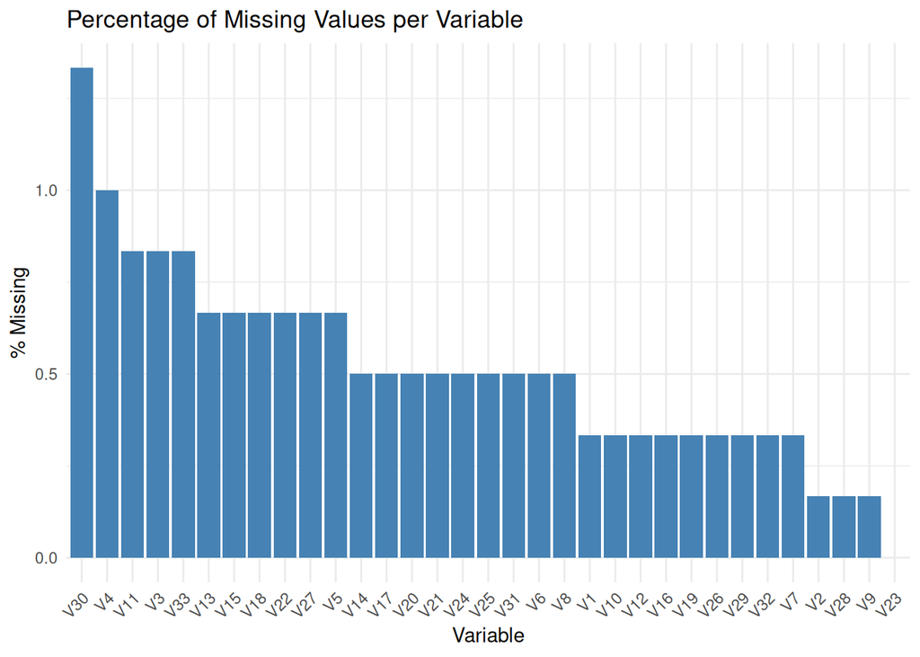

```r
ggplot(miss_summary, aes(x = reorder(variable, -pct_miss), y = pct_miss)) +
  geom_col(fill = "steelblue") +
  labs(title = "Percentage of Missing Values per Variable",
       x = "Variable", y = "% Missing") +
  theme_minimal() +
  theme(axis.text.x = element_text(angle = 45, hjust = 1))
```

Across the board, all variables but one have missing values (that of V23). However, the percentage of missing values is less than 2% across all variables. This is promising and may suggest that we do not have to impute any missing values.

We proceed to visualise missingness further, in order to analyse any patterns within our dataset and make a final verdict on imputing missing values.

#### Overall missingness map

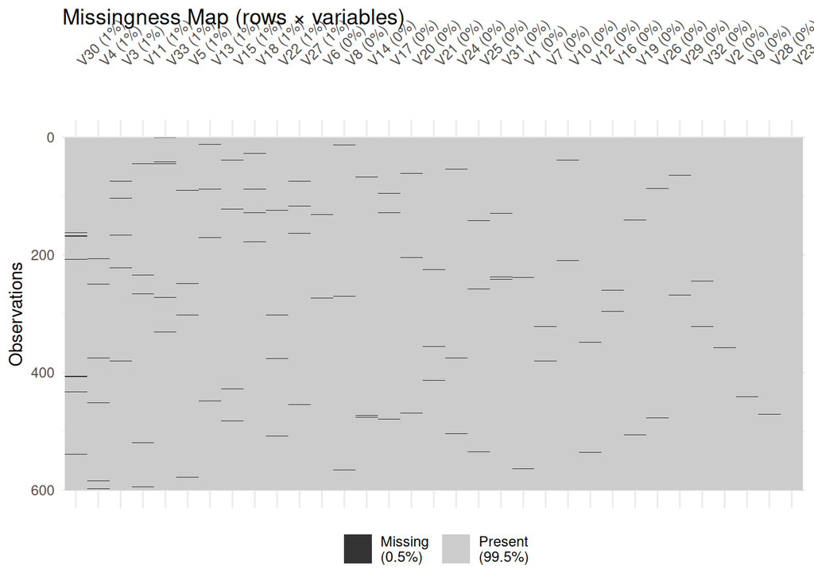

```r
vis_miss(chromo, sort_miss = TRUE) +
  labs(title = "Missingness Map (rows × variables)")
```

The missingness map provides an overview of every cell in the dataset. It confirms that our missingness is low, at 0.5% overall. It also shows us the concentration of missingness, which in this case does not seem to follow an obvious pattern. The lines, indicating missingness, seem to be randomly distributed both across observations (rows) and variables. No variable is disproportionately affected, and there is no row-level systematic pattern.

Given the tiny proportion of missing values, and the random concentration, imputing missing values would likely introduce small bias using simple methods such as mean/median imputation. More complex methods also appear unnecessary here.

#### Co-missingness patterns

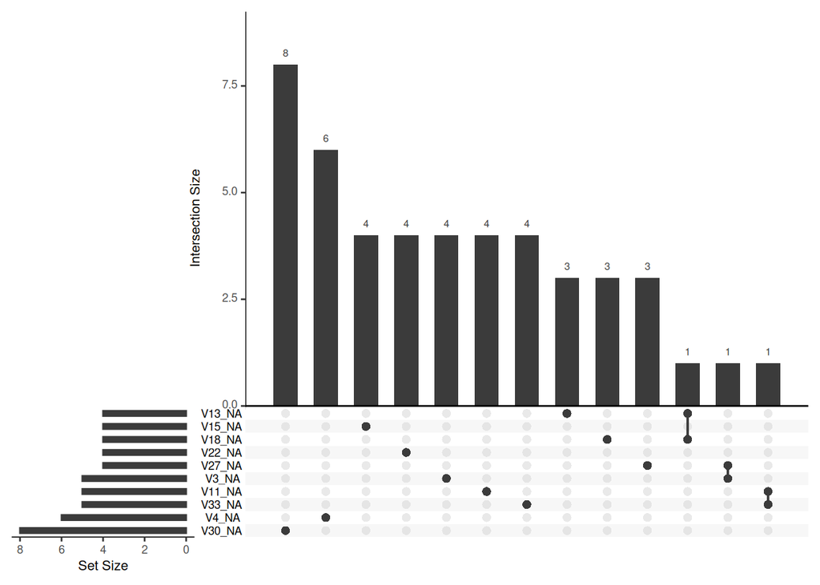

```r
n_vars_with_miss <- sum(miss_summary$n_miss > 0)
gg_miss_upset(chromo, nsets = min(n_vars_with_miss, 10))
```

Our intersection plot shows that most missingness is unique. There is very little co-missingness, that of three connected dots in our graph, showing intersection sizes of one. This appears negligible to our future analysis.

Missingness does not appear monotone, as missing values are spread across variables without consistent pairing.

There also does not seem to be any evidence of a pipeline failure, as there are no large intersection bars with multiple missing variables.

#### Missing values by observation

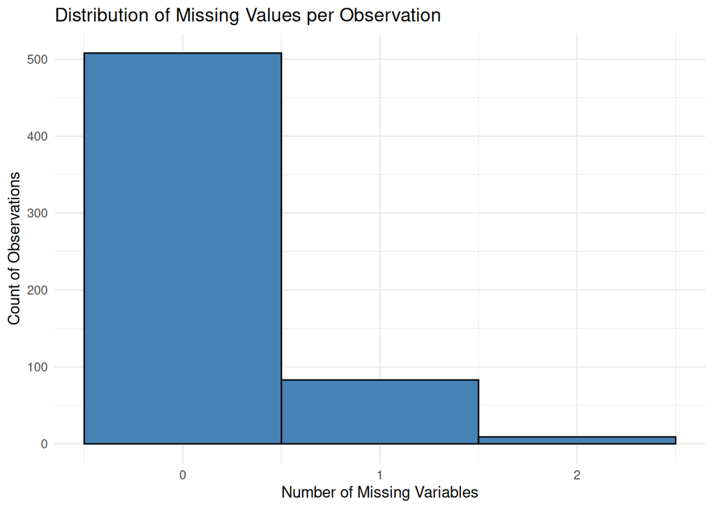

```r
obs_miss <- chromo %>%
  mutate(row_id = row_number(),
         n_miss = rowSums(is.na(.))) %>%
  select(row_id, n_miss)

ggplot(obs_miss, aes(x = n_miss)) +
  geom_histogram(binwidth = 1, fill = "steelblue", color = "black") +
  labs(title = "Distribution of Missing Values per Observation",
       x = "Number of Missing Variables", y = "Count of Observations") +
  theme_minimal()
```

The vast majority of rows, 500+ out of 600 do not exhibit missing values. Single value missingness is then most common, and there is a max of 2 values missing per observation.

##### Due to the above analysis, I see no reason to impute missing values. Missingness appears randomly scattered, and there are no patterns of concern within variables, observations or co-missingness.

### Structure analysis

As our data has 33 variables, bivariate plots are insufficient. We use dimension reduction methods to inspect the structure of our data.

#### Correlation analysis

```r
chromo_na_dropped <- chromo %>% drop_na()
cat("Complete cases available:", nrow(chromo_na_dropped), "of", nrow(chromo), "\n")
```

```
## Complete cases available: 508 of 600
```

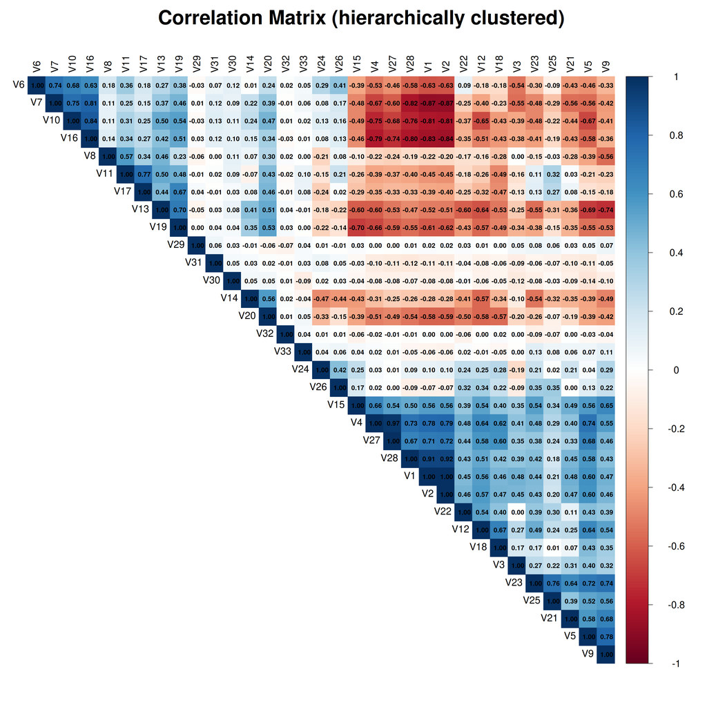

```r
cor_mat <- cor(chromo_na_dropped)

corrplot(cor_mat,
         method   = "color",
         type     = "upper",
         order    = "hclust",      # cluster correlated variables together
         tl.cex   = 1.5,
         cl.cex = 1.5,
         tl.col   = "black",
         addCoef.col = "black",
         number.cex = 1,
         mar      = c(0, 0, 2, 0))

title("Correlation Matrix (hierarchically clustered)",
      cex.main = 3,
      font.main = 2,
      line = 1)
```

Many of the pairwise correlations between these clusters have values in the range of 0.4 - 0.8, and in some cases higher. This indicates that the variables could be measuring related or overlapping features.

In the top right of the correlation plot, you can see strong negative correlations. After further inspection, it seems that this negative correlation is actually between the intersection of the two clusters, indicating that the features are measuring opposing or complementary signals. For example, chromosomes have two arms, designated a long arm and short arm. These opposing signals may be measuring features of each arm, such as length, leading to a negative correlation between the clusters.

There is a cluster of variables in the middle of the plot with close to zero correlation, indicating that these variables may carry independent information not captured by the two dominant groups.

Overall, it seems that dimensionality reduction, such as PCA would be effective here, as we may be able to capture the variance within these clusters with a reduced amount of variables, due to the strong correlation.

#### Principal Components Analysis

We perform PCA on the scaled (unit-variance, zero-mean) data with missing values dropped. This ensures that all variables can contribute equally to the decomposition. As PCA uses euclidean distance, if the range of variable x has range 500, and y has range 5, then variable x will dominate our analysis regardless of if the variable is actually more informative. As a result, we must scale the data to ensure there is no implicit weighting. We also drop NA values as PCA requires a complete covariance matrix, and as discussed earlier, we do not have a strong justification to impute NA values in this scenario.

```r
pca_result <- prcomp(chromo_na_dropped, center = TRUE, scale. = TRUE)
```

#### Scree plot and Cumulative variance explained plot

We continue with a scree plot, to see the proportion of total variance captured by each successive principle component. As well as this, we use a cumulative variance explained graph to further explain which principle components to select.

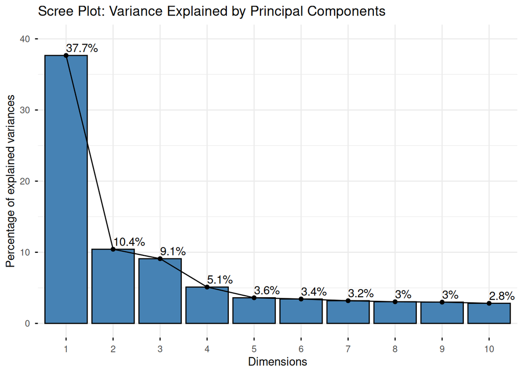

```r
fviz_eig(pca_result,
         addlabels = TRUE,
         ylim = c(0, 40),
         barfill = "steelblue",
         barcolor = "black",
         main = "Scree Plot: Variance Explained by Principal Components")
```

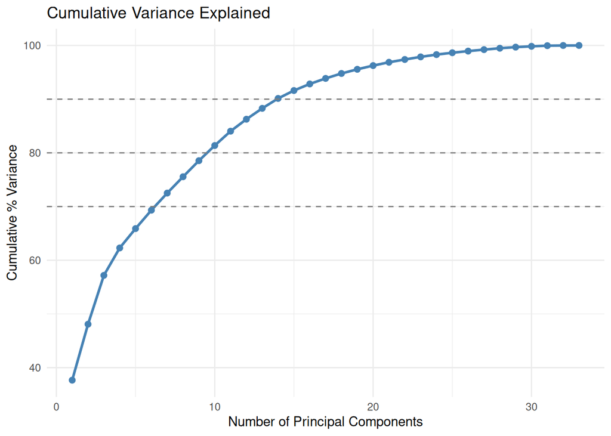

```r
cum_var <- cumsum(pca_result$sdev^2 / sum(pca_result$sdev^2)) * 100
var_df <- data.frame(PC = seq_along(cum_var), CumulativeVariance = cum_var)

ggplot(var_df, aes(x = PC, y = CumulativeVariance)) +
  geom_line(colour = "steelblue", linewidth = 1) +
  geom_point(colour = "steelblue", size = 2) +
  geom_hline(yintercept = c(70, 80, 90), linetype = "dashed", colour = "grey50") +
  labs(title = "Cumulative Variance Explained",
       x = "Number of Principal Components",
       y = "Cumulative % Variance") +
  theme_minimal()
```

From these two graphs, we have a number of key observations about how we may proceed with clustering.

- PC1 is dominant - PC1 captures 37.7% of the variation within the data, confirming the strong correlation clusters we found earlier.
- PC3 Elbow - There is an elbow after PC3 in our scree plot, indicating that PC1 - PC3 captures most of the variation within the data. After PC3, each successive principle component only adds roughly 3% of the variation, which could be structural or could be noise.
- Cumulative Variance - To reach an 80% threshold of variance captured within the data, we need 10 principle components. This indicates that there are multiple sources of variation beyond the two clusters we found earlier in the correlation matrix.

```r
cat("PCs to reach 60% variance:", which(cum_var >= 60)[1], "\n")
```

```
## PCs to reach 60% variance: 4
```

```r
cat("PCs to reach 70% variance:", which(cum_var >= 70)[1], "\n")
```

```
## PCs to reach 70% variance: 7
```

```r
cat("PCs to reach 80% variance:", which(cum_var >= 80)[1], "\n")
```

```
## PCs to reach 80% variance: 10
```

```r
cat("PCs to reach 90% variance:", which(cum_var >= 90)[1], "\n")
```

```
## PCs to reach 90% variance: 14
```

Although to reach a larger cumulative variance amount we may need 10+ clusters, for analytical purposes we may be able to get away with 3-7 clusters in practice. This seems to retain the dominant biological structure of the chromosomes without over-fitting for noise.

#### Score scatterplot

We use score scatterplots (Plotting PC1 against PC2) as further graphical evidence for cluster structure.

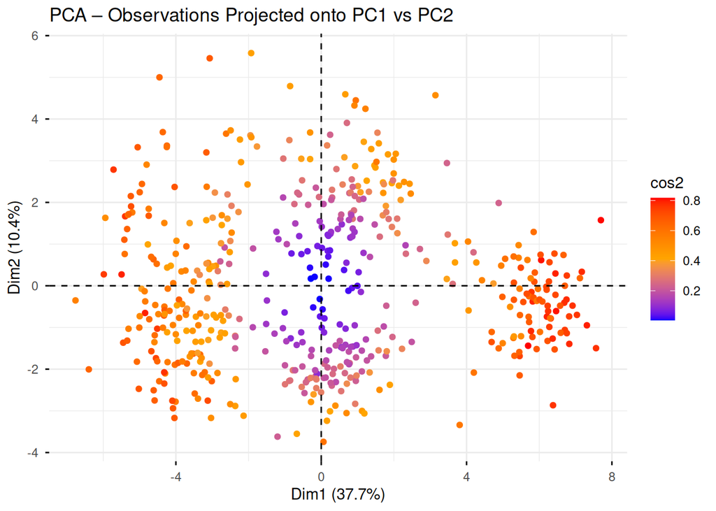

```r
fviz_pca_ind(pca_result,
             geom.ind = "point",
             col.ind  = "cos2",
             gradient.cols = c("blue", "orange", "red"),
             pointsize = 1.5,
             title = "PCA – Observations Projected onto PC1 vs PC2")
```

PC1 shows a clear horizontal spread, indicating that PC1 is discriminating between our observations strongly, and capturing structures within the data.

PC2 shows vertical spread, albeit not as strongly as PC1. However, it still suggests being able to capture a second independent source of variation.

Observations with a high cos2, shown in red and orange sit mainly at the extremes of PC1. As this metric represents how well a particular observation is represented in the reduced PCA space, this means PC1 clearly defines these observations.

On the other end, we have a cluster of observations towards the centre of the graph with low cos2 values. This indicates that these observations are poorly explained by PC1 and PC2, and their variation may be better explained in PC3 and beyond. We proceed to plot PC3 and PC4 to further explore these structures.

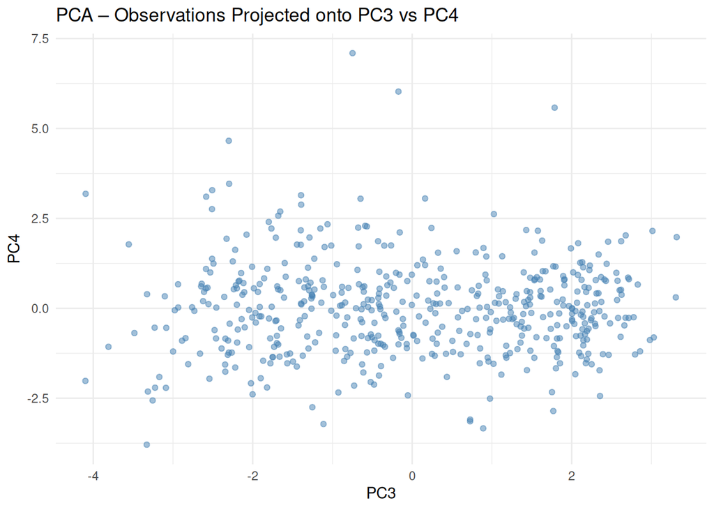

```r
pca_scores <- as.data.frame(pca_result$x)

ggplot(pca_scores, aes(x = PC3, y = PC4)) +
  geom_point(alpha = 0.5, size = 1.5, colour = "steelblue") +
  labs(title = "PCA – Observations Projected onto PC3 vs PC4",
       x = "PC3", y = "PC4") +
  theme_minimal()
```

Our plot of PC3 vs PC4 is structureless, with no seeming directional spread or grouping. This indicates that PC3 and beyond are capturing minor sources of variation that do not have an obvious structure.

This seems to validate the initial scree plot, which suggested that only PC1 to PC3 were worth retaining.

#### PCA Loadings

Analysing the PCA loadings can suggest to us which variables drive each principal components. Variables with near-zero loadings on PC1-PC3 can suggest little contribution to the structure of our data, and to discriminatory information. These can be candidates for removal. Similarly, variables with large loadings can suggest the largest drivers to our principle components.

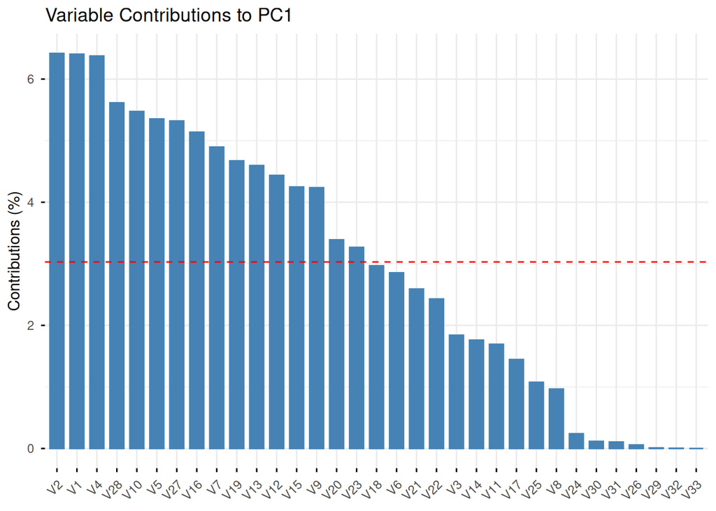

```r
fviz_contrib(pca_result, choice = "var", axes = 1,
             title = "Variable Contributions to PC1", top = 33)
```

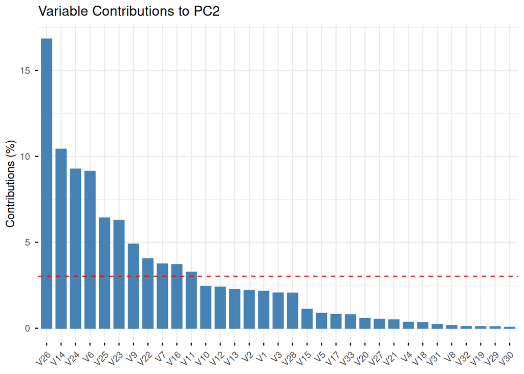

```r
fviz_contrib(pca_result, choice = "var", axes = 2,
             title = "Variable Contributions to PC2", top = 33)
```

```r
loadings_PC5 <- as.data.frame(pca_result$rotation[, 1:5])
loadings_PC5$variable <- rownames(loadings_PC5)
loadings_PC5 <- loadings_PC5 %>% select(variable, everything())

knitr::kable(loadings_PC5, digits = 3,
             caption = "PCA loadings for the first five components") %>%
  kable_styling(
    bootstrap_options = c("striped", "hover", "condensed"),
    full_width = FALSE
  )
```

PCA loadings for the first five components

|  | variable | PC1 | PC2 | PC3 | PC4 | PC5 |
| --- | --- | --- | --- | --- | --- | --- |
| V1 | V1 | 0.253 | -0.147 | 0.015 | -0.104 | 0.164 |
| V2 | V2 | 0.253 | -0.148 | 0.006 | -0.122 | 0.161 |
| V3 | V3 | 0.136 | -0.143 | 0.159 | 0.057 | 0.020 |
| V4 | V4 | 0.253 | -0.059 | -0.002 | -0.101 | -0.201 |
| V5 | V5 | 0.231 | 0.093 | 0.131 | 0.148 | -0.224 |
| V6 | V6 | -0.169 | 0.302 | -0.154 | -0.164 | -0.098 |
| V7 | V7 | -0.221 | 0.193 | -0.187 | 0.060 | -0.202 |
| V8 | V8 | -0.098 | -0.040 | 0.186 | -0.551 | 0.048 |
| V9 | V9 | 0.206 | 0.221 | 0.084 | 0.348 | 0.002 |
| V10 | V10 | -0.234 | 0.156 | -0.090 | 0.131 | 0.076 |
| V11 | V11 | -0.130 | 0.181 | 0.387 | -0.255 | 0.017 |
| V12 | V12 | 0.211 | 0.155 | -0.094 | -0.200 | -0.132 |
| V13 | V13 | -0.214 | -0.150 | 0.123 | -0.183 | 0.199 |
| V14 | V14 | -0.133 | -0.323 | -0.001 | 0.138 | -0.263 |
| V15 | V15 | 0.206 | 0.105 | 0.025 | 0.025 | 0.073 |
| V16 | V16 | -0.227 | 0.192 | -0.079 | 0.139 | 0.034 |
| V17 | V17 | -0.120 | 0.089 | 0.424 | -0.088 | -0.036 |
| V18 | V18 | 0.172 | 0.058 | -0.274 | -0.129 | -0.175 |
| V19 | V19 | -0.216 | -0.030 | 0.160 | -0.030 | -0.011 |
| V20 | V20 | -0.184 | -0.076 | 0.222 | 0.102 | -0.178 |
| V21 | V21 | 0.161 | 0.070 | 0.265 | 0.259 | 0.327 |
| V22 | V22 | 0.156 | 0.201 | -0.119 | -0.215 | -0.196 |
| V23 | V23 | 0.181 | 0.250 | 0.284 | 0.075 | 0.008 |
| V24 | V24 | 0.049 | 0.304 | -0.212 | 0.022 | 0.486 |
| V25 | V25 | 0.104 | 0.253 | 0.337 | 0.028 | -0.162 |
| V26 | V26 | 0.024 | 0.410 | -0.039 | -0.211 | -0.023 |
| V27 | V27 | 0.231 | -0.072 | -0.026 | -0.115 | -0.250 |
| V28 | V28 | 0.237 | -0.143 | 0.024 | -0.122 | 0.162 |
| V29 | V29 | 0.010 | 0.029 | 0.026 | 0.123 | -0.058 |
| V30 | V30 | -0.034 | 0.023 | -0.028 | -0.161 | 0.158 |
| V31 | V31 | -0.033 | 0.047 | -0.065 | 0.067 | 0.138 |
| V32 | V32 | -0.007 | -0.032 | -0.029 | -0.056 | 0.152 |
| V33 | V33 | 0.000 | 0.089 | 0.079 | 0.105 | -0.183 |

```r
k <- 5
max_abs_loading <- apply(abs(pca_result$rotation[, 1:k]), 1, max)
low_load_vars <- names(max_abs_loading[max_abs_loading < 0.15])
cat("Variables with max |loading| < 0.15 across first", k, "PCs:\n")
```

```
## Variables with max |loading| < 0.15 across first 5 PCs:
```

```r
cat(paste(low_load_vars, collapse = ", "), "\n")
```

```
## V29, V31
```

We find that PC1 has 16 variables that exceed the threshold, so a large number of variables drive the principle component. On the other hand, PC2 has 11 variables above the threshold, but unlike PC1, PC22 is highly dominated by V26 at more than 15% contribution. This means that PC2 is much more concentrated, with a less variables being the key drivers to the principle component.

Finally, we have two variables with a max loading under 0.15 for the first 5 principle components. These variables contribute very little to any of the first 5 principle components, so could be the first candidates for removal.

### Identifying Uninformative or Anomalous Variables

#### Near Zero Variance Variables

```r
var_vec <- chromo_na_dropped %>% summarise(across(everything(), var)) %>%
  pivot_longer(everything(), names_to = "variable", values_to = "variance") %>%
  arrange(variance)

median_var <- median(var_vec$variance)
nzv_threshold <- 0.01 * median_var

nzv_vars <- var_vec %>% filter(variance < nzv_threshold)

knitr::kable(var_vec, digits = 2,
             caption = "Variance of each variable (ascending)") %>%
  kable_styling(
    bootstrap_options = c("striped", "hover", "condensed"),
    full_width = FALSE
  )
```

Variance of each variable (ascending)

| variable | variance |
| --- | --- |
| V31 | 7.64 |
| V33 | 7.72 |
| V30 | 8.43 |
| V32 | 8.59 |
| V29 | 8.69 |
| V3 | 4945.94 |
| V10 | 5250.97 |
| V7 | 5392.87 |
| V6 | 5415.94 |
| V8 | 5910.69 |
| V12 | 6249.22 |
| V24 | 6336.50 |
| V18 | 6782.73 |
| V26 | 7331.73 |
| V25 | 8270.62 |
| V16 | 8323.73 |
| V27 | 8624.42 |
| V5 | 8678.75 |
| V14 | 8891.59 |
| V9 | 9520.14 |
| V15 | 9666.82 |
| V22 | 9784.56 |
| V11 | 9939.23 |
| V28 | 9942.73 |
| V21 | 10550.63 |
| V17 | 10863.24 |
| V19 | 11513.51 |
| V20 | 12269.50 |
| V4 | 12334.50 |
| V13 | 12909.21 |
| V2 | 15115.32 |
| V23 | 15313.02 |
| V1 | 17525.37 |

```r
if (nrow(nzv_vars) > 0) {
  cat("Near-zero variance variables (< 1% of median variance):\n")
  print(nzv_vars)
} else {
  cat("No near-zero variance variables detected.\n")
}
```

```
## Near-zero variance variables (< 1% of median variance):
## # A tibble: 5 × 2
##   variable variance
##   <chr>       <dbl>
## 1 V31          7.64
## 2 V33          7.72
## 3 V30          8.43
## 4 V32          8.59
## 5 V29          8.69
```

We flag V29-V33 as near-zero variance, making them very strong candidates for removal. That being said, these were initial flagged for having much smaller intervals than the rest of our variables, which would heavily affect variance without standardisation.

However, during PCA, where we do standardise, we still find these variables towards the bottom of the loadings during PC1 and PC2, in particular V29 and V31, although some variables contribute a small but potentially significant amount of variance during PC4-5 (above 0.1).

I have chosen here to be conservative, and keep in some of these variables. While PCA and our correlation analysis identified them as uninformative, PCA by method down weights low-information variables. To add to this, the nature of the data (interval, mean, median etc), is vastly different from the rest of the variables, and so I have reason to suspect that these variables may be banding pattern information. As a result we only choose to discard V29 and V31, those who had near-zero variance as well as PCA loadings under 0.15 for the first 5 PCAs.

```r
candidates <- list(
  near_zero_var    = if (nrow(nzv_vars) > 0) nzv_vars$variable else character(0),
  low_pca_loading  = low_load_vars
)

cat("Candidates for removal:\n")
```

```
## Candidates for removal:
```

```r
print(candidates)
```

```
## $near_zero_var
## [1] "V31" "V33" "V30" "V32" "V29"
##
## $low_pca_loading
## [1] "V29" "V31"
```

```r
# Variables flagged by ≥ 2 diagnostics are strong removal candidates
all_candidates <- unlist(candidates)
if (length(all_candidates) > 0) {
  freq <- table(all_candidates)
  cat("\nVariables flagged by ≥ 2 diagnostics:\n")
  print(freq[freq >= 2])
} else {
  cat("\nNo variables flagged by multiple diagnostics.\n")
}
```

```
##
## Variables flagged by ≥ 2 diagnostics:
## all_candidates
## V29 V31
##   2   2
```

```r
# Apply removal (adjust as needed based on your specific seed/sample)
vars_to_remove <- unique(all_candidates[duplicated(all_candidates)])
if (length(vars_to_remove) > 0) {
  cat("\nRemoving:", paste(vars_to_remove, collapse = ", "), "\n")
  chromo_clean <- chromo %>% select(-all_of(vars_to_remove))
} else {
  cat("\nNo variables meet the multi-diagnostic removal criterion.",
      "Retaining all variables.\n")
  chromo_clean <- chromo
}
```

```
##
## Removing: V29, V31
```

#### Outlier detection via Modified Z-scores (MAD)

```r
modified_z <- chromo_na_dropped %>%
  mutate(across(everything(), ~ {
    med <- median(., na.rm = TRUE)
    mad_val <- mad(., constant = 1, na.rm = TRUE)
    if (mad_val == 0) rep(0, length(.)) else 0.6745 * (. - med) / mad_val
  }))

outlier_counts <- modified_z %>%
  summarise(across(everything(), ~ sum(abs(.) > 3.5))) %>%
  pivot_longer(everything(), names_to = "variable", values_to = "n_outliers") %>%
  arrange(desc(n_outliers))

knitr::kable(outlier_counts, caption = "Number of outliers per variable (|Modified Z| > 3.5)") %>%
  kable_styling(
    bootstrap_options = c("striped", "hover", "condensed"),
    full_width = FALSE
  )
```

Number of outliers per variable (|Modified Z| > 3.5)

| variable | n_outliers |
| --- | --- |
| V8 | 3 |
| V19 | 3 |
| V20 | 3 |
| V12 | 2 |
| V24 | 2 |
| V25 | 2 |
| V27 | 2 |
| V3 | 1 |
| V9 | 1 |
| V1 | 0 |
| V2 | 0 |
| V4 | 0 |
| V5 | 0 |
| V6 | 0 |
| V7 | 0 |
| V10 | 0 |
| V11 | 0 |
| V13 | 0 |
| V14 | 0 |
| V15 | 0 |
| V16 | 0 |
| V17 | 0 |
| V18 | 0 |
| V21 | 0 |
| V22 | 0 |
| V23 | 0 |
| V26 | 0 |
| V28 | 0 |
| V29 | 0 |
| V30 | 0 |
| V31 | 0 |
| V32 | 0 |
| V33 | 0 |

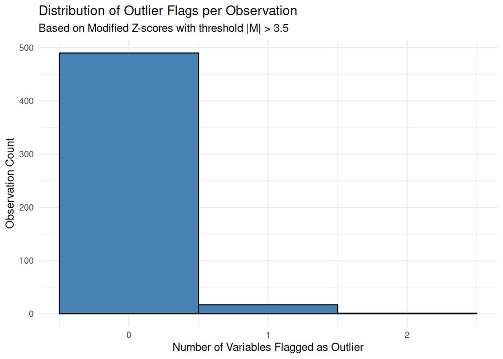

```r
obs_outlier <- rowSums(abs(modified_z) > 3.5)

ggplot(data.frame(n_outlier_flags = obs_outlier), aes(x = n_outlier_flags)) +
  geom_histogram(binwidth = 1, fill = "steelblue", colour = "black") +
  labs(title = "Distribution of Outlier Flags per Observation",
       subtitle = "Based on Modified Z-scores with threshold |M| > 3.5",
       x = "Number of Variables Flagged as Outlier",
       y = "Observation Count") +
  theme_minimal()
```

```r
cat("Observations flagged as outliers on ≥ 5 variables:",
    sum(obs_outlier >= 2), "\n")
```

[output not shown]

We find some isolated outliers within our variables. However, these are consistent with biological distributions, which may exhibit some heavy-tail properties. We check for outliers across multiple variables, and find that only 1 outlier sits across 2 or more variables. As a result, I find no evidence of outliers and no reason to remove any observations across the dataset.

#### Scaling Justification

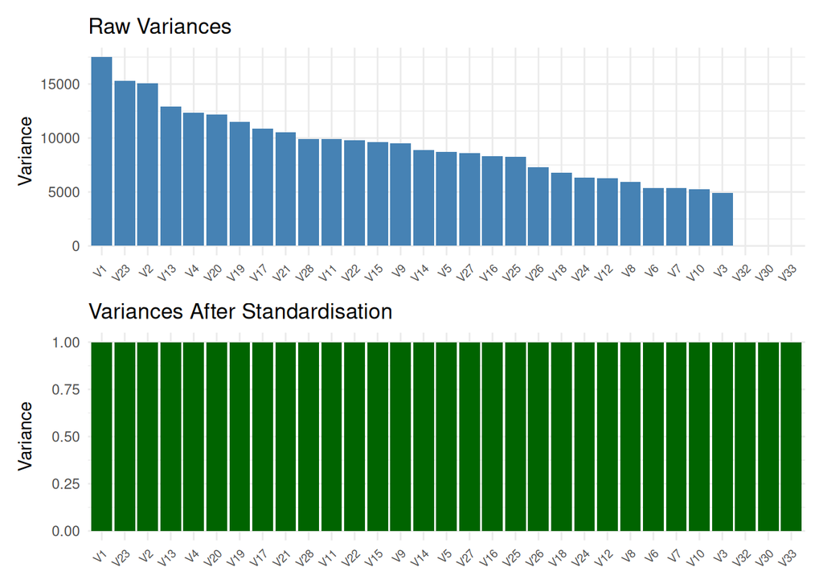

```r
chromo_clean_na_dropped <- chromo_clean %>% drop_na()

# Raw variances
raw_var <- apply(chromo_clean_na_dropped, 2, var)

# Scaled variances (should all be 1)
scaled_data <- scale(chromo_clean_na_dropped)
scaled_var <- apply(scaled_data, 2, var)

var_comp <- data.frame(
  variable = names(raw_var),
  raw_variance = raw_var,
  scaled_variance = scaled_var
)

p1 <- ggplot(var_comp, aes(x = reorder(variable, -raw_variance), y = raw_variance)) +
  geom_col(fill = "steelblue") +
  labs(title = "Raw Variances", x = NULL, y = "Variance") +
  theme_minimal() +
  theme(axis.text.x = element_text(angle = 45, hjust = 1, size = 7))

p2 <- ggplot(var_comp, aes(x = reorder(variable, -raw_variance), y = scaled_variance)) +
  geom_col(fill = "darkgreen") +
  labs(title = "Variances After Standardisation", x = NULL, y = "Variance") +
  theme_minimal() +
  theme(axis.text.x = element_text(angle = 45, hjust = 1, size = 7))

p1 / p2
```

```r
cat("Ratio of max to min raw variance:",
    round(max(raw_var) / min(raw_var), 1), "\n")
```

```
## Ratio of max to min raw variance: 2250.6
```

The ratio of the largest to smallest raw variance is substantial (reported above). Without standardisation, PCA would effectively become a summary of the highest- variance features alone, and k-means would partition the data based disproportionately on those same features.

We therefore choose to standardise all variables to zero mean and unit variance before any subsequent clustering analysis.

## Question 2 - Cluster Structure and Comparison

### Standard Euclidian Route

#### Missingness handling

In our EDA, we saw that missingness was scattered rather than concentrated. This means that column-mean imputation would lead to minor distortion. As well as this, Casewise deletion under random missingness can lead to a large number of rows, and thus a large fraction of the sample deleted. For k-means clustering, loosing observations would be more damaging than a reduction in variance, as it is less data from which to learn the clustering.

As a result, we choose column-mean imputation, as it would have the a mitigated negative affect on the data compared to casewise deletion.

```r
chromo_imputed <- chromo_clean
for (j in seq_len(ncol(chromo_imputed))) {
  na_idx <- is.na(chromo_imputed[[j]])
  if (any(na_idx)) {
    chromo_imputed[[j]][na_idx] <- mean(chromo_imputed[[j]], na.rm = TRUE)
  }
}
cat("Remaining NAs after imputation:", sum(is.na(chromo_imputed)), "\n")
```

```
## Remaining NAs after imputation: 0
```

```r
cat("Sample size retained:", nrow(chromo_imputed), "\n")
```

```
## Sample size retained: 600
```

```r
# Standardise to zero mean, unit variance (justified in Section 5)
chromo_scaled <- as.data.frame(scale(chromo_imputed))
```

#### Running k-means

```r
set.seed(270)

k_range <- 2:7
wss_A <- numeric(length(k_range))
km_list_A <- list()

for (i in seq_along(k_range)) {
  km <- kmeans(chromo_scaled, centers = k_range[i], nstart = 25, iter.max = 100)
  wss_A[i] <- km$tot.withinss
  km_list_A[[i]] <- km
}

elbow_A <- data.frame(k = k_range, WSS = wss_A)
```

#### Elbow plot

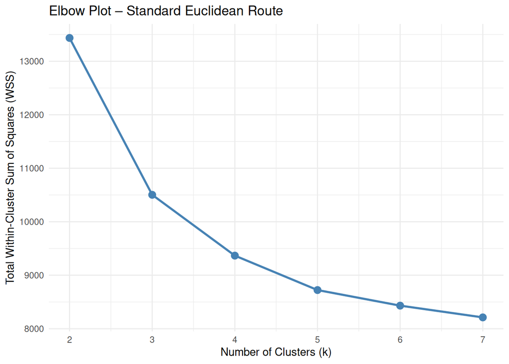

```r
ggplot(elbow_A, aes(x = k, y = WSS)) +
  geom_line(colour = "steelblue", linewidth = 1) +
  geom_point(colour = "steelblue", size = 3) +
  scale_x_continuous(breaks = k_range) +
  labs(title = "Elbow Plot – Standard Euclidean Route",
       x = "Number of Clusters (k)",
       y = "Total Within-Cluster Sum of Squares (WSS)") +
  theme_minimal()
```

```r
# Tabulate marginal decreases to help locate the elbow
elbow_A$decrease <- c(NA, -diff(elbow_A$WSS))
elbow_A$pct_decrease <- c(NA, round(-diff(elbow_A$WSS) / head(elbow_A$WSS, -1) * 100, 2))
knitr::kable(elbow_A, digits = 2, format = "markdown",
             caption = "WSS and marginal decrease per k (Standard Euclidean)")
```

WSS and marginal decrease per k (Standard Euclidean)

| k | WSS | decrease | pct_decrease |
| --- | --- | --- | --- |
| 2 | 13435.99 | NA | NA |
| 3 | 10503.36 | 2932.64 | 21.83 |
| 4 | 9366.50 | 1136.86 | 10.82 |
| 5 | 8722.87 | 643.63 | 6.87 |
| 6 | 8431.46 | 291.41 | 3.34 |
| 7 | 8211.87 | 219.59 | 2.60 |

Unfortunately, there’s not a clear K selection in this case, with the graph appearing smooth and continuously declining, so the data may not have strong cluster boundaries.

We show the graph of the percentage point decrease per k, and use this to help us select. We could select k=3, due to an extra k only improving WSS by roughly 10%.

However, K=4 provides the last practically meaningful improvement, before marginal and potential unimportant differences. As well as this, during our PC1-PC2 projection in our EDA, the data seemed to be grouped into 4 clusters, rather than 3 intuitively.

#### Cluster Visualisation via PCA

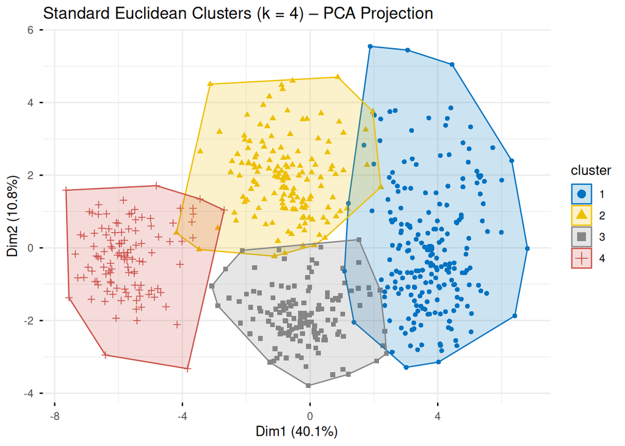

```r
k_A <-4

km_A <- km_list_A[[which(k_range == k_A)]]

fviz_cluster(km_A, data = chromo_scaled,
             geom = "point",
             pointsize = 1.5,
             ellipse.type = "convex",
             palette = "jco",
             ggtheme = theme_minimal(),
             main = paste0("Standard Euclidean Clusters (k = ", k_A,
                           ") – PCA Projection"))
```

### Observed Only Normalised Distance Route

#### Embed and Run the k-means

We compute the renormalised euclidean distance, embed with a classical (metric) MDS as we did in the lectures/labs with 2D embedding, and run the k-means.

```r
# Scale without imputing: scale() on columns, NA propagated
chromo_scaled_raw <- as.data.frame(scale(chromo_clean))
X <- as.matrix(chromo_scaled_raw)
n <- nrow(X)
p <- ncol(X)

# Compute the n x n renormalised distance matrix
dist_mat <- matrix(0, nrow = n, ncol = n)

for (i in 1:(n - 1)) {
  for (j in (i + 1):n) {
    # Identify coordinates observed in BOTH rows
    obs_both <- which(!is.na(X[i, ]) & !is.na(X[j, ]))
    n_obs <- length(obs_both)
    if (n_obs > 0) {
      partial_ss <- sum((X[i, obs_both] - X[j, obs_both])^2)
      dist_mat[i, j] <- sqrt(p / n_obs * partial_ss)
    } else {
      dist_mat[i, j] <- NA
    }
    dist_mat[j, i] <- dist_mat[i, j]
  }
}

# Report any pairs with zero shared observations
n_na_pairs <- sum(is.na(dist_mat[upper.tri(dist_mat)]))
cat("Observation pairs with no shared variables:", n_na_pairs, "\n")
```

```
## Observation pairs with no shared variables: 0
```

```r
# Handle any NA distances by substituting the median distance
if (n_na_pairs > 0) {
  med_dist <- median(dist_mat, na.rm = TRUE)
  dist_mat[is.na(dist_mat)] <- med_dist
  cat("Replaced with median distance:", round(med_dist, 3), "\n")
}

dist_obj <- as.dist(dist_mat)
```

```r
mds_result <- cmdscale(dist_obj, k = 2, eig = TRUE)
mds_coords <- mds_result$points
colnames(mds_coords) <- c("MDS1", "MDS2")

# Goodness-of-fit: proportion of variance explained by the 2D embedding
mds_eig <- mds_result$eig
mds_var_explained <- sum(mds_eig[1:2]) / sum(abs(mds_eig)) * 100
cat(sprintf("Variance explained by 2D MDS embedding: %.1f%%\n", mds_var_explained))
```

```
## Variance explained by 2D MDS embedding: 47.7%
```

```r
set.seed(270)

wss_B <- numeric(length(k_range))
km_list_B <- list()

for (i in seq_along(k_range)) {
  km <- kmeans(mds_coords, centers = k_range[i], nstart = 25, iter.max = 100)
  wss_B[i] <- km$tot.withinss
  km_list_B[[i]] <- km
}

elbow_B <- data.frame(k = k_range, WSS = wss_B)
```

#### Elbow Plot

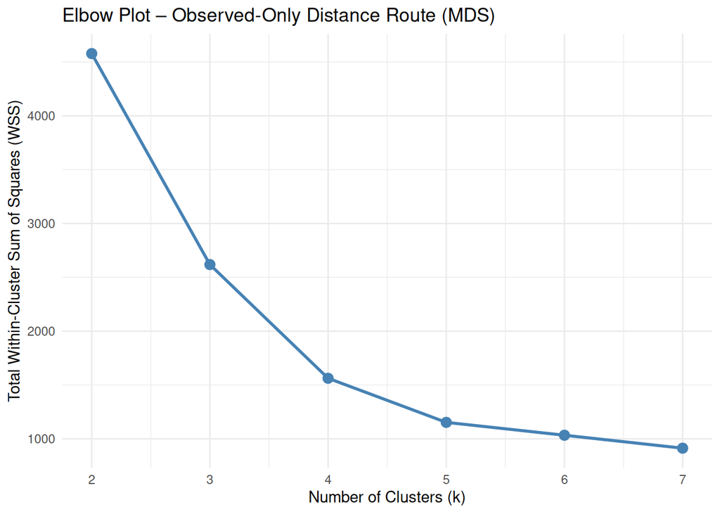

```r
ggplot(elbow_B, aes(x = k, y = WSS)) +
  geom_line(colour = "steelblue", linewidth = 1) +
  geom_point(colour = "steelblue", size = 3) +
  scale_x_continuous(breaks = k_range) +
  labs(title = "Elbow Plot – Observed-Only Distance Route (MDS)",
       x = "Number of Clusters (k)",
       y = "Total Within-Cluster Sum of Squares (WSS)") +
  theme_minimal()
```

```r
elbow_B$decrease <- c(NA, -diff(elbow_B$WSS))
elbow_B$pct_decrease <- c(NA, round(-diff(elbow_B$WSS) / head(elbow_B$WSS, -1) * 100, 2))
knitr::kable(elbow_B, digits = 2, format = "markdown",
             caption = "WSS and marginal decrease per k (Observed-Only MDS)") %>%
  kable_styling(
    bootstrap_options = c("striped", "hover", "condensed"),
    full_width = FALSE
  )
```

WSS and marginal decrease per k (Observed-Only MDS)

| k | WSS | decrease | pct_decrease |
| --- | --- | --- | --- |
| 2 | 4578.16 | NA | NA |
| 3 | 2618.20 | 1959.96 | 42.81 |
| 4 | 1562.09 | 1056.11 | 40.34 |
| 5 | 1152.48 | 409.61 | 26.22 |
| 6 | 1033.08 | 119.41 | 10.36 |
| 7 | 912.81 | 120.27 | 11.64 |

We choose k = 4, as from k = 4->5, we see the curve start to flatten noticable. Beyond this point, clusters will yield diminishing results, and could just be partitioning existing structures instead of capturing new groupings.

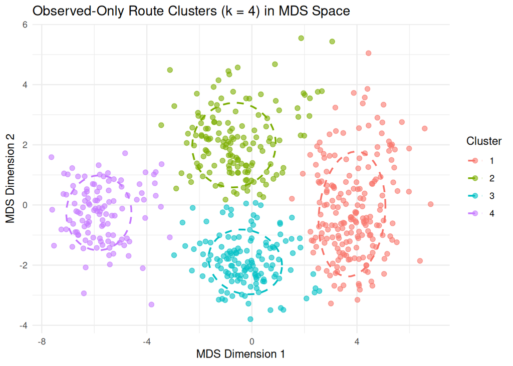

```r
k_B <- 4
km_B <- km_list_B[[which(k_range == k_B)]]

mds_df <- as.data.frame(mds_coords)
mds_df$cluster <- factor(km_B$cluster)

ggplot(mds_df, aes(x = MDS1, y = MDS2, colour = cluster)) +
  geom_point(alpha = 0.6, size = 2) +
  stat_ellipse(level = 0.68, linewidth = 0.8, linetype = "dashed") +
  labs(title = paste0("Observed-Only Route Clusters (k = ", k_B,
                      ") in MDS Space"),
       x = "MDS Dimension 1", y = "MDS Dimension 2",
       colour = "Cluster") +
  theme_minimal()
```

### Comparison of the Two Clusterings

We cross-tabulate the two cluster vectors to see which labels from Route A most frequently co-occur with which labels from Route B. We then calculate the proportion of differing assignments using the logic from the labs (where different rankings are compared for stability), we count mismatches and divide by n.

```r
labels_A <- km_A$cluster   # from Standard Euclidean Route
labels_B <- km_B$cluster   # from Observed-Only Distance Route

cat("Length of Euclidean cluster vector:", length(labels_A), "\n")
```

```
## Length of Euclidean cluster vector: 600
```

```r
cat("Length of Observed-Only cluster vector:", length(labels_B), "\n")
```

```
## Length of Observed-Only cluster vector: 600
```

```r
cross_tbl <- table(Euclidean = labels_A, ObservedOnly = labels_B)
knitr::kable(cross_tbl, format = "markdown",
             caption = "Cross-tabulation of cluster assignments (raw labels)") %>%
  kable_styling(
    bootstrap_options = c("striped", "hover", "condensed"),
    full_width = FALSE
  )
```

Cross-tabulation of cluster assignments (raw labels)

| 1 | 2 | 3 | 4 |
| --- | --- | --- | --- |
| 197 | 10 | 3 | 0 |
| 1 | 136 | 4 | 2 |
| 2 | 0 | 131 | 1 |
| 0 | 1 | 0 | 112 |

```r
if (k_A == k_B) {
  # The proportion of observations where the aligned labels disagree
  prop_diff <- mean(labels_A != labels_B)
  n_diff <- sum(labels_A != labels_B)
  n_total <- length(labels_A)

  cat(sprintf("Number of differing assignments: %d / %d\n", n_diff, n_total))
  cat(sprintf("Proportion of differing assignments: %.4f (%.1f%%)\n",
              prop_diff, prop_diff * 100))
} else {
  cat("Direct proportion not computed (different k values selected).\n")
}
```

```
## Number of differing assignments: 24 / 600
## Proportion of differing assignments: 0.0400 (4.0%)
```

As you can see, there is a very low level of differing assignments, at 4%. As well as this, both routes identify the same optimal k, indicating that this is the correct k to identify a genuine structure. The low level of differing assignments indicates that boundary choices are flipping between clusters, and the cluster choices are meaningful and stable. We seem to have identified actually biological groupings in the features, and not just noise or an artefact from a processing choices.

## Question 3 - Cluster Interpretation

We select our preferred pipleline, euclidean.

```r
preferred <- "euclidean"

km_preferred <- km_A
data_preferred <- chromo_scaled
k <- k_A
```

#### Constructing cluster prototypes

```r
centroids <- as.data.frame(km_preferred$centers)
centroids$Cluster <- factor(1:k)

# Display the centroid matrix
centroids_display <- centroids %>% select(Cluster, everything())
knitr::kable(centroids_display, digits = 2, format = "markdown",
             caption = "Cluster centroids (standardised scale)")  %>%
  kable_styling(
    bootstrap_options = c("striped", "hover", "condensed"),
    full_width = FALSE
  )
```

Cluster centroids (standardised scale)

| Cluster | V1 | V2 | V3 | V4 | V5 | V6 | V7 | V8 | V9 | V10 | V11 | V12 | V13 | V14 | V15 | V16 | V17 | V18 | V19 | V20 | V21 | V22 | V23 | V24 | V25 | V26 | V27 | V28 | V30 | … |
| --- | --- | --- | --- | --- | --- | --- | --- | --- | --- | --- | --- | --- | --- | --- | --- | --- | --- | --- | --- | --- | --- | --- | --- | --- | --- | --- | --- | --- | --- | --- |
| 1 | -1.04 | -1.03 | -0.63 | -0.87 | -0.91 | 0.79 | 1.13 | 0.06 | -0.79 | 0.99 | 0.07 | -0.66 | 0.63 | 0.61 | -0.79 | 0.98 | 0.01 | -0.29 | 0.68 | 0.48 | -0.95 | -0.44 | -1.04 | -0.14 | -0.71 | -0.12 | -0.75 | -0.97 | 0.05 | … |
| 2 | -0.20 | -0.22 | 0.10 | 0.07 | 0.63 | 0.20 | -0.08 | 0.22 | 0.71 | -0.11 | 0.90 | 0.42 | -0.51 | -0.78 | 0.40 | 0.08 | 0.74 | -0.27 | -0.06 | 0.14 | 0.59 | 0.46 | 1.19 | 0.11 | 1.03 | 0.73 | -0.04 | -0.18 | 0.02 | … |
| 3 | 0.55 | 0.54 | 0.40 | 0.00 | -0.13 | -0.86 | -0.85 | 0.26 | -0.26 | -0.32 | 0.08 | -0.62 | 0.67 | 0.36 | -0.09 | -0.55 | 0.35 | -0.52 | 0.19 | 0.32 | 0.59 | -0.82 | 0.03 | -0.26 | 0.00 | -0.71 | -0.02 | 0.52 | 0.01 | … |
| 4 | 1.53 | 1.56 | 0.56 | 1.54 | 1.05 | -0.68 | -1.00 | -0.69 | 0.87 | -1.33 | -1.37 | 1.44 | -1.32 | -0.57 | 1.06 | -1.28 | -1.37 | 1.49 | -1.40 | -1.44 | 0.33 | 1.21 | 0.40 | 0.43 | 0.00 | 0.13 | 1.46 | 1.42 | -0.13 | … |

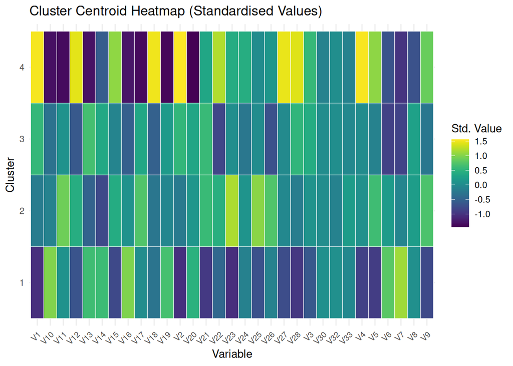

```r
centroids_long <- centroids %>%
  pivot_longer(-Cluster, names_to = "Variable", values_to = "Value")

ggplot(centroids_long, aes(x = Variable, y = Cluster, fill = Value)) +
  geom_tile(colour = "white") +
  scale_fill_viridis() +
  labs(title = "Cluster Centroid Heatmap (Standardised Values)",
       x = "Variable", y = "Cluster", fill = "Std. Value") +
  theme_minimal() +
  theme(axis.text.x = element_text(angle = 45, hjust = 1, size = 8))
```

Rows with strikingly different colour profiles represent well-separated chromosome classes while rows with similar profiles suggest classes that may be harder to distinguish. We find that cluster 4 is the most well separated, while the other classes still have distinguishable separation.

#### Visualising cluster differences

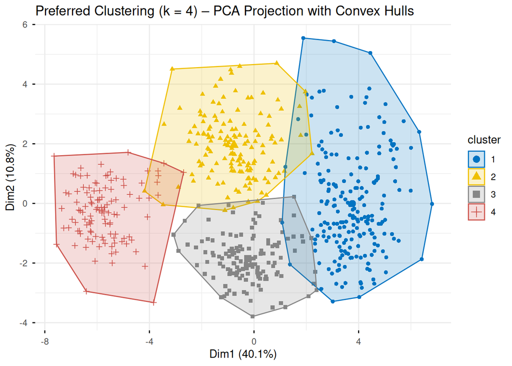

```r
fviz_cluster(km_preferred, data = data_preferred,
             geom = "point",
             pointsize = 1.5,
             ellipse.type = "convex",
             palette = "jco",
             ggtheme = theme_minimal(),
             main = paste0("Preferred Clustering (k = ", k,
                           ") – PCA Projection with Convex Hulls"))
```

```r
centroids_numeric <- centroids %>% select(-Cluster)
centroid_spreads <- apply(centroids_numeric, 2, function(x) diff(range(x)))
top_vars <- names(sort(centroid_spreads, decreasing = TRUE))[1:min(6, ncol(centroids_numeric))]
cat("Top discriminating variables (by centroid spread):\n")
```

```
## Top discriminating variables (by centroid spread):
```

```r
cat(paste(top_vars, collapse = ", "), "\n")
```

```
## V2, V1, V4, V28, V10, V11
```

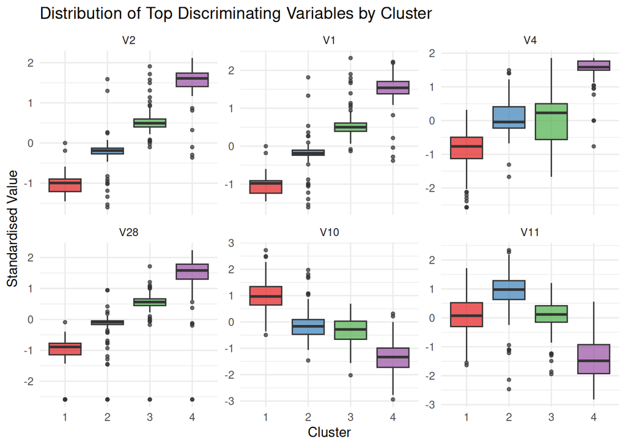

```r
box_data <- as.data.frame(data_preferred)
box_data$Cluster <- factor(km_preferred$cluster)

box_long <- box_data %>%
  select(Cluster, all_of(top_vars)) %>%
  pivot_longer(-Cluster, names_to = "Variable", values_to = "Value") %>%
  mutate(Variable = factor(Variable, levels = top_vars))

ggplot(box_long, aes(x = Cluster, y = Value, fill = Cluster)) +
  geom_boxplot(outlier.size = 1, alpha = 0.7) +
  facet_wrap(~ Variable, scales = "free_y", ncol = 3) +
  scale_fill_brewer(palette = "Set1") +
  labs(title = "Distribution of Top Discriminating Variables by Cluster",
       x = "Cluster", y = "Standardised Value") +
  theme_minimal() +
  theme(legend.position = "none")
```

#### Number of Chromosome Classes

I think there are 4 chromosome classes, because of these points throughout our analysis:

- Agreement throughout the different methods — two completely different analytical approaches (Euclidean and MDS) both independently pointed to k=4 as the best number of clusters, and assigned 96% of chromosomes to the same group.
- Group profiles — looking at the boxplots, each cluster has a distinctly different pattern across the key measurements. Cluster 1 is consistently low on some features and high on others, while Cluster 4 is the complete opposite, with Clusters 2 and 3 sitting in between. This suggests 4 classes, although it could suggest one class with a continuous distribution.
- The PCA plot visually suggested four groups visually.
- Adding more than 4 clusters stopped being useful — beyond k=4, each additional cluster only marginally provided improvements meaning extra clusters could just be artificially splitting existing groups rather than finding new genuine structure in the data.

#### Within cluster variability

```r
within_ss <- data.frame(
  Cluster = factor(1:k),
  WithinSS = km_preferred$withinss,
  Size = km_preferred$size
)

# Normalise by cluster size for fair comparison
within_ss$AvgWithinSS <- within_ss$WithinSS / within_ss$Size

knitr::kable(within_ss, digits = 2, format = "markdown",
             caption = "Within-cluster sum of squares and cluster sizes")  %>%
  kable_styling(
    bootstrap_options = c("striped", "hover", "condensed"),
    full_width = FALSE
  )
```

Within-cluster sum of squares and cluster sizes

| Cluster | WithinSS | Size | AvgWithinSS |
| --- | --- | --- | --- |
| 1 | 3526.40 | 210 | 16.79 |
| 2 | 2146.15 | 143 | 15.01 |
| 3 | 1961.65 | 134 | 14.64 |
| 4 | 1732.30 | 113 | 15.33 |

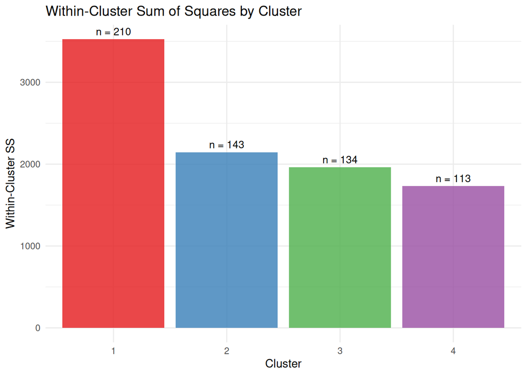

```r
ggplot(within_ss, aes(x = Cluster, y = WithinSS, fill = Cluster)) +
  geom_col(alpha = 0.8) +
  geom_text(aes(label = paste0("n = ", Size)), vjust = -0.5, size = 3.5) +
  scale_fill_brewer(palette = "Set1") +
  labs(title = "Within-Cluster Sum of Squares by Cluster",
       x = "Cluster", y = "Within-Cluster SS") +
  theme_minimal() +
  theme(legend.position = "none")
```

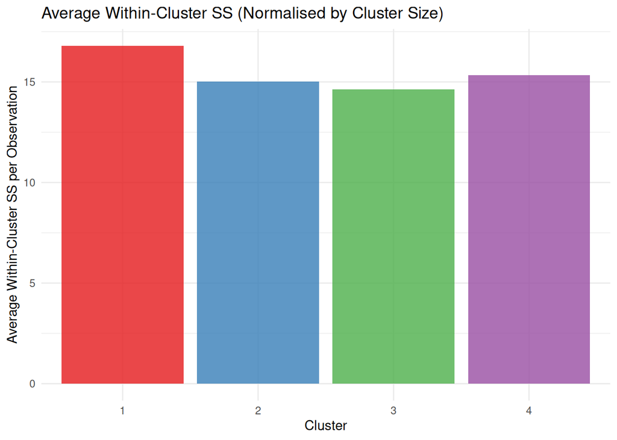

```r
ggplot(within_ss, aes(x = Cluster, y = AvgWithinSS, fill = Cluster)) +
  geom_col(alpha = 0.8) +
  scale_fill_brewer(palette = "Set1") +
  labs(title = "Average Within-Cluster SS (Normalised by Cluster Size)",
       x = "Cluster", y = "Average Within-Cluster SS per Observation") +
  theme_minimal() +
  theme(legend.position = "none")
```

- Cluster 1 appears much more spread out than the others in our first graph, but this is simply because it contains nearly twice as many observations (210 vs 113–143).
- Therefore we decide to normalise by cluster. WSS is divided by the number of observations in each cluster leading to all four clusters show very similar average spread (~15–17 per observation), meaning no cluster is dramatically tighter or looser than the others.
- All clusters are of comparable quality — the similarity in normalised WSS suggests k-means hasn’t created one artificially tight cluster while leaving others sprawling, which would be a sign of a poor clustering solution. These results help us justifyk=4 decisionas there is good and equal internal cohesion across clusters.

#### **Uncertainty and Sensitivity to Modelling Choices**

Any cluster analysis carries inherent uncertainty.

In Question 2, we found that only **4.0%** of observations received different cluster assignments under the two pipelines. This low proportion indicates that the identified classes are robust to the choice of missing-data strategy and distance representation. We can be reasonably confident that the cluster structure reflects genuine biological groupings rather than artefacts of preprocessing.

The cluster labels (1, 2, 3, 4) assigned by `kmeans()` are arbitrary and carry no inherent biological meaning. We used `nstart = 25` to ensure stability of the solution, reducing the risk of a poor local optimum. That being said, the partition depends on the choice of k, the distance metric, and the preprocessing — all of which involve judgement. The gradient structure observed across clusters (Cluster 1 being the polar opposite of Cluster 4) may suggest that these are not 4 distinct classes, but rather points across a continuous class.